# Temporal biodiversity change following disturbance varies along an environmental gradient - Kaarlejärvi - 2021 - Global Ecology and Biogeography - Wiley Online Library

[Global Ecology and Biogeography](https://onlinelibrary.wiley.com/journal/14668238)

[Volume 30, Issue 2](https://onlinelibrary.wiley.com/toc/14668238/2021/30/2)

RESEARCH PAPER

Open Access

# Temporal biodiversity change following disturbance varies along an environmental gradient

[Elina Kaarlejärvi](https://onlinelibrary.wiley.com/action/doSearch?ContribAuthorStored=Kaarlej%C3%A4rvi%2C+Elina)

[Maija Salemaa](https://onlinelibrary.wiley.com/action/doSearch?ContribAuthorStored=Salemaa%2C+Maija)

[Tiina Tonteri](https://onlinelibrary.wiley.com/action/doSearch?ContribAuthorStored=Tonteri%2C+Tiina)

[Päivi Merilä](https://onlinelibrary.wiley.com/action/doSearch?ContribAuthorStored=Meril%C3%A4%2C+P%C3%A4ivi)

[Anna‐Liisa Laine](https://onlinelibrary.wiley.com/action/doSearch?ContribAuthorStored=Laine%2C+Anna-Liisa)

First published: 08 December 2020

https://doi.org/10.1111/geb.13233

## Abstract

### Aim

The diversity and composition of natural communities are rapidly changing due to anthropogenic disturbances. Magnitude of this compositional reorganization varies across the globe, but reasons behind the variation remain largely unknown. Disturbances induce temporal turnover by stimulating species colonizations, causing local extinctions, altering dominance structure, or all of these. We test which of these processes drive temporal community changes, and whether they are constrained by natural environmental gradients. Moreover, we assess to what degree identity shifts translate to changes in dominance structure.

### Location

Finland.

### Time period

Observations 1985–2006, disturbance history > 140 years.

### Major taxa studied

Vascular plants.

### Methods

We investigated temporal turnover of boreal forest understorey in response to disturbance, here forest management, along a soil fertility gradient. We disentangle the roles of species gains, losses and abundance changes in driving temporal turnover in response to and after disturbance by comparing turnover rates in different forest age categories along a fertility gradient. We quantify temporal turnover using richness‐based complement of Jaccard’s similarity index and proportional‐abundance based dissimilarity index. We also test whether disturbance history or fertility influence the relationship between identity shifts and dominance structure.

### Results

We found that the impact of disturbance on temporal turnover depends on soil fertility. The greatest turnover occurred in the most fertile forests immediately after disturbance. There, species gains and losses strongly altered dominance structure leading to high turnover, whereas undisturbed old forests and nutrient‐poor habitats were characterized by stable dominant species even when the majority of species shifted their identity.

### Main conclusions

Our results suggest that human impacts on temporal biodiversity change vary along environmental gradients. In boreal forests, the fertile habitats have a higher probability than nutrient‐poor sites of changing their composition in response to anthropogenic disturbances. Resource availability and disturbance history may thus influence consequences of temporal turnover for ecosystem functioning.

## 1 INTRODUCTION

Anthropogenic pressure on the remaining ecosystems and their biodiversity is accelerating (Arneth et al., 2019; IPBES, 2019; Sala, 2000). Recent ecological research has highlighted the need to consider community changes more broadly than changes in species richness alone to better understand the causes and consequences of observed biodiversity changes (Blowes et al., 2019; Chase et al., 2018; Hillebrand et al., 2018). Ecological communities change as species become more or less abundant, go (locally) extinct or colonize new habitats, and consequently substantial community changes may not be captured by metrics focusing on species richness alone. To identify what makes an ecosystem susceptible to disturbance, and to predict consequences of disturbance, we therefore need to know which processes underlie community change, and whether environmental gradients influence the strength of these processes, and thus the magnitude of change.

To date, the spatial dimension of biodiversity change has been the focus of research, while the constraints and drivers of temporal turnover remain less known (e.g., Magurran et al., 2019). By temporal turnover we mean changes in the identities and/or the abundances of species in a community over time. Observational evidence suggests that temporal turnover is higher in the marine than the terrestrial realm (Blowes et al., 2019), decreases with altitude (Bunn et al., 2010) and increases along productivity (Maliniemi et al., 2019; Virtanen et al., 2010; Zhang et al., 2018) and temperature gradients (Hillebrand et al., 2010). As these environmental gradients influence natural biodiversity change over time, they also have the potential to regulate the magnitude of anthropogenic disturbance‐induced turnover. Theoretically, as predicted by the dynamic equilibrium model (Huston, 1979), community turnover is maximized by a combination of high community productivity, which speeds up competitive exclusion, and high frequency of disturbances, which removes some of the species, thereby creating opportunities for others to establish. While we have evidence that productivity and disturbances jointly influence species richness, as shown by means of meta‐analysis (Worm et al., 2002), spatially replicated field samples (Cardinale et al., 2006) and models (Kondoh, 2001; Lehsten & Kleyer, 2007), the tests of these drivers of temporal turnover remain rare and come from small‐scale experiments (Wilson & Tilman, 2002). At a time when anthropogenic disturbances increasingly modify communities around the globe, we critically need to know how environmental gradients influence the impacts of disturbances on temporal turnover of communities at broad geographical scales.

Disturbance type is expected to be critical for how we expect biodiversity to change (Dornelas, 2010), but also time since disturbance is known to greatly influence temporal turnover (Anderson, 2007). Successional theory predicts a decreasing number of species gains and losses with time since disturbance, but we lack knowledge on how temporal turnover varies over time and along environmental gradients (Anderson, 2007). This is probably due to the scarcity of suitable long‐term biodiversity datasets that would allow identification of community changes in relation to disturbance events across varying environmental conditions. Since disturbance severity also influences magnitude of temporal turnover (e.g., Chang et al., 2019), and the community responses to disturbance appear after a time‐lag (Daskalova et al., 2020; Komatsu et al., 2019), it is crucial to observe development of temporal turnover over time to disentangle the effects of human actions from the natural background change that is an inherent property of most natural systems (Hillebrand et al., 2018; Magurran et al., 2010). Collectively, this evidence illustrates that in order to evaluate the vulnerability and responses of communities to disturbances, we need to quantify how processes causing temporal turnover, that is, colonizations, extinctions and abundance changes, vary both along environmental gradients and over time after different disturbance types.

Globally temporal turnover is driven more strongly by species replacement than by shifts in richness (Blowes et al., 2019) implying that colonizations of better‐suited species often compensate local extinctions (Supp & Ernest, 2014). But to what degree do these identity shifts alter community composition and functioning of the communities? The answer depends on the relationship between identity and dominance shifts, also called rank shifts (Hillebrand et al., 2018; Magurran et al., 2019): if identity shifts are positively associated with dominance shifts, it means that colonizers gain high abundances, while some previously dominant species become less common. If ecosystem processes (Allan et al., 2011; Sasaki & Lauenroth, 2011) and stability (Cottingham et al., 2001; Hillebrand et al., 2008) are driven by dominant species and their traits, then shifts in dominance structure will alter functioning of the communities if traits of new colonizers differ from those of previous dominants. However, despite the potential of this relationship between temporal identity and dominance shifts to reveal insights on the importance of species losses and gains at community and ecosystem level, we lack knowledge on its variation in nature.

Boreal forests represent the largest terrestrial biome on Earth, providing a multitude of ecosystem services (Gauthier et al., 2015). Forest understorey harbours up to 80% of the vascular plant diversity and plays an important role in ecosystem functioning (Gilliam, 2007; Landuyt et al., 2019; Nilsson & Wardle, 2005). Forests are increasingly used by humans (Potapov et al., 2017) and therefore, understanding the consequences of frequent disturbances, that is, forest management practices, is crucial both for the development of ecological sustainability, and for protecting the biodiversity of this key ecosystem. In this study, we assess temporal community change of vascular plant understorey communities in response to forest management practices along a soil fertility gradient. Environmental gradients such as soil fertility, temperature, and precipitation often correlate with habitat productivity, species growth rates and species richness (e.g., Chapin et al., 1993; Chown et al., 2000; Whittaker, 1975), which may all influence the rate and extent by which species change over time in communities. We measure soil fertility with the carbon (C) to nitrogen (N) ratio, which is a widely used measure of the limiting resource (nitrogen) in the boreal forests (Hasselman, 1926; Heikkinen & Mäkipää, 2010; Högberg et al., 2017). We quantify temporal community change by five measures: relative abundance‐based turnover, richness‐based turnover, species gains, species losses and change in species richness (detailed in the Materials and methods) both as short‐term responses of communities to disturbance as well as their long‐term dynamics (Figure 1). First, to understand how temporal turnover of understorey communities develops through time after a major disturbance (here regeneration cutting, such as clear‐cutting), we analysed the community change during a 10‐year undisturbed sampling period in forest stands differing in time since disturbance and soil fertility. These analyses enable comparison of temporal turnover in recently disturbed versus naturally changing communities along a fertility gradient. We also evaluated whether disturbance history or soil fertility influence the relationship between identity shifts and dominance structure. Second, to assess whether the disturbance intensities, here three types of silvicultural practices, differ in their short‐term effects on understorey composition depending on soil fertility, we analysed how community change from before to after disturbance was related to time since disturbance and fertility. As predicted by the dynamic equilibrium theory (Huston, 1979), we expect to find greatest temporal turnover following the strongest disturbance (regeneration cutting) in sites characterized by high soil fertility.

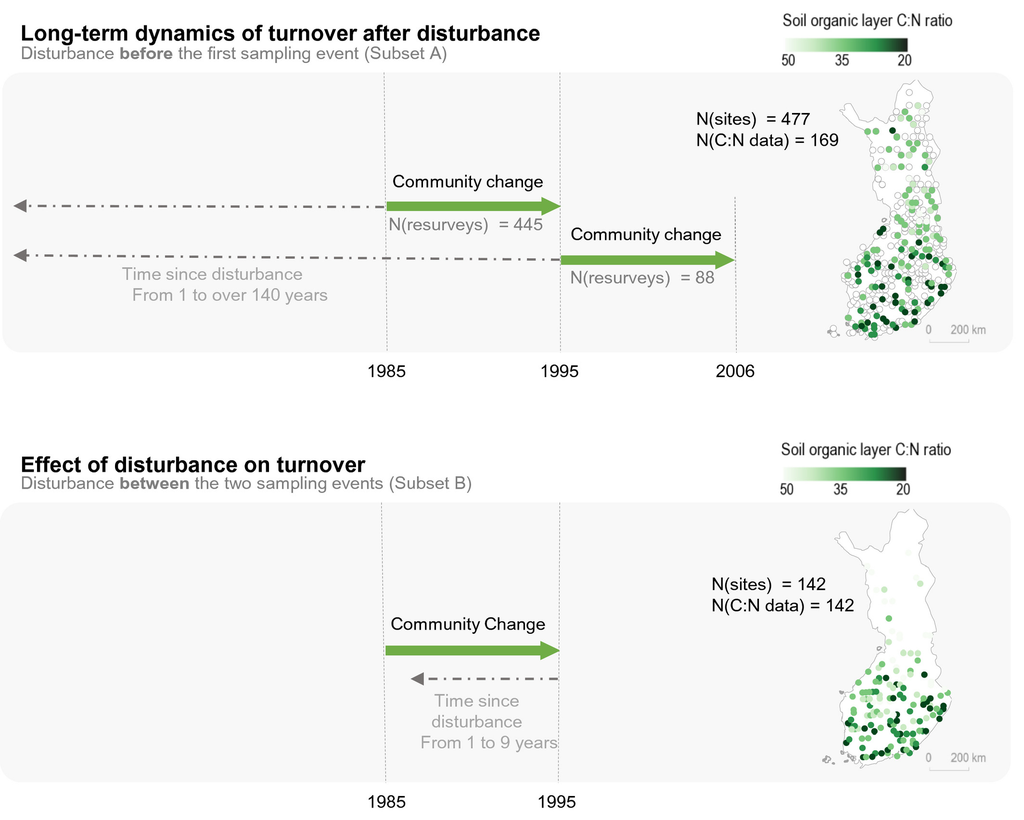

**FIGURE 1**

Data compilation and study site locations in Finland. The grey panels show how two subsets of understorey community data were compiled to study long‐term dynamics of turnover (subset A) and the effect of disturbance on turnover (subset B). Both data subsets contain two consecutive surveys of vascular plant communities in boreal forest understorey (dashed vertical lines), but differ in timing of disturbance in relation to the surveys: in data subset A disturbance took place from 1 to over 140 years before the first sampling, while in data subset B disturbance took place between the two sampling events allowing us to compare community composition before and after a disturbance. The subset A comprises of 533 resurveys on 477 sites, as some of the sites were re‐sampled in both 1995 and 2006 and experienced no disturbance between the sampling events. Circles on the map show the study site locations. Data on soil organic layer carbon (C) to nitrogen (N) ratio were collected in the coloured sites in 2006. Low C : N ratio indicates fertile soils

## 2 MATERIALS AND METHODS

### 2.1 Study area and sampling design

Understorey vegetation was surveyed on a systematic network of 1,700 sites established on mineral‐soil in forested land in 1985–1986. These sites are a part of a systematic sampling network of the 8th Finnish National Forest Inventory (Reinikainen et al., 2000). This network consists of clusters, which were located 16 km from each other in southern Finland, and 24 and 32 km apart in northern Finland along east–west and north–south axes, respectively. Each cluster consists of four linearly located sampling sites 400 m apart from each other in southern Finland and three sampling sites 600 m apart from each other in northern Finland. All 1,700 sites were resurveyed in 1995, and a subset of 443 of them (max. 1 site per cluster) were resurveyed in 2006 (Figure 1). The spatial extent of this subset was comparable to previous surveys covering the whole country. The survey performed on 443 sites in 2006 was part of the BioSoil project carried out under the Forest Focus scheme, which is a subset of the pan‐European International Co‐operative Programme on Assessment and Monitoring of Air Pollution Effects on Forests (UN‐ECE ICP) monitoring site network (Level I, Lorenz & Fischer, 2013).

### 2.2 Vegetation, soil and temperature data

The understorey vegetation of boreal forest comprises the field layer (consisting of small tree and shrub seedlings and saplings, dwarf shrubs, herbs and graminoids) and the ground layer (consisting of bryophytes and lichens) (Nilsson & Wardle, 2005). In all three surveys, vascular plant species were identified and each species’ cover (0.1–100%) was visually estimated on the same four permanent square‐shaped sampling plots of 2 m<sup>2</sup>, located 5 m apart from each other within each site. In the data analysis, we use the average of species cover across the four sampling plots as an estimate of species abundance at each site. Presence of vascular plant species outside sampling quadrats but inside the 300‐m<sup>2</sup> circular site was recorded in 1985–1986 and 1995. We defined ‘local species pool’ as the total number of unique species occurring in a site, encountered either in or outside of the plots, but within the boundaries of the circular 300‐m<sup>2</sup> site.

In 2006, 10 or 20 subsamples were systematically collected with a cylinder (diameter = 60 mm) from the organic layer of 443 sites (400 m<sup>2</sup>, Figure 1). Number of subsamples depended on the organic layer thickness to yield equal soil volume per site. Subsamples were pooled to one composite sample per site. Total C and N contents of the composite samples were determined on a LECO CHN analyser. This C : N ratio in the organic layer was used as a retrospective indicator of the fertility also in 1985 and 1995, since inter‐annual variation in organic layer C : N is low (0–20% during 16 years, Olsson et al., 1996) and silvicultural practices have little or no effect on it (Johnson & Curtis, 2001). To describe the differences in effective temperatures between sites, we calculated daily mean temperature sum exceeding +5 °C (i.e., growing degree days over + 5 °C, GDD5) for each site for a 10‐year period prior to each survey. Daily temperature data were obtained from the Finnish Meteorological Institute’s interpolation onto a 10 km × 10 km grid (Venäläinen et al., 2005).

### 2.3 Disturbance history of sites

During each survey, the disturbance history of each site was classified by recording disturbance type (nine forest management categories) and time since the latest disturbance (three categories: 1, 2–5, 6–10 years). We grouped the nine disturbance categories into the following three groups: ‘Regeneration cuttings’, which includes all regenerative cuttings (seed tree cutting, shelterwood cutting, strip clear‐cutting, clear‐cutting with a nurse crop, clear‐cutting); ‘Commercial thinning’, which includes commercial thinning, selection cutting and removal of reserve trees; and ‘Pre‐commercial tending’, which includes pre‐commercial thinning and cleaning of the sapling stand (descriptions of management types in Supporting Information Table S1). Additionally, disturbance history for the preceding 5 years was visually estimated with 1‐year accuracy based on the state of stumps and cutting residues in 1990 and 1995 yielding annual data on disturbance history for the period 1985–1995. By combining all these recordings, we could determine the time and type of the latest disturbance event for each site for the period 1975–2006 (Figure 1). To estimate the timing of the latest major disturbance event before 1975, we used stand age (measured dendrochronologically from a cored sample tree per site, or counting branch whirls of younger trees) as a proxy for a disturbance that removed most of the canopy. Because time since disturbance was recorded using three categories during 1975–1985, we categorized also stand age to the following categories: 31–60, 61–80, 81–100, 101–120, 121–140 and over 140 years.

### 2.4 Calculating community indices

Observations of two subspecies were merged to species level and observations of group taxa above genus level were removed from the data. To characterize the change over time in understorey communities, we calculated five temporal community change metrics. First, we calculated change in species richness between two time steps. Second, we calculated species gains as the number of species that appeared in the later sampling relative to first sampling. Third, species losses were computed as the number of species that disappeared in the later sampling relative to first sampling. Fourth, to characterize the proportion of species that changed identity between the two sampling events, we calculated richness‐based turnover [richness‐based species exchange ratio, SERr, sensu Hillebrand et al. (2018)] as summed species gains and losses relative to species richness across both sampling events. This is a complement of Jaccard’s similarity index and based on presence–absence data (Jaccard, 1912). Fifth, to characterize changes in species’ relative abundances over time, we calculated relative abundance‐based turnover (abundance‐based species exchange ratio, SERa, sensu Hillebrand et al., 2018). Abundance‐based turnover is thus the most comprehensive measure of community change of these five metrics. Since it is based on relative abundances, it illustrates shifts in the dominant species and avoids being sensitive to species richness and changes in rare species (Hillebrand et al., 2018). We opted to work with these temporal turnover measures, since they allow investigation of how dominance and identity shift in communities over time. Richness‐based turnover was calculated using the codyn package (Hallett et al., 2016).

### 2.5 Statistical modelling

Based on literature (Antão et al., 2020; Hillebrand et al., 2010; Kraft et al., 2011; Wilson & Tilman, 2002) of the predictors available to us, we would expect soil fertility, effective temperature sum (measured as GDD5 over the preceding 10 years) and local species pool at the site to influence temporal turnover. To understand which of these is most relevant in our data, we compared their abilities to explain variation in abundance‐based turnover. Both temperature sum and local species pool correlated negatively with organic layer C : N (*r* = −.64, *p* < .001; and *r* = −.65, *p* < .001, respectively). We used the data subset A with C : N values (*n* = 169) and ran three generalized linear mixed effect models, where the fixed factor consisted of interaction between time since disturbance and one of these three variables in turn and compared fits of these models to data by Akaike’s information criterion (AIC). In these models, the random variable consisted of site nested within the bioclimatic subzone. We calculated explanatory powers of the fixed variables in each of the three models [marginal *R*<sup>2</sup>, according to Nakagawa and Schielzeth (2013) in the piecewiseSEM package (Lefcheck et al., 2018)]. Since C : N ratio explained more variation in abundance‐based turnover than GDD5 or local species pool (47 vs. 39 or 40%, respectively, Supporting Information Figure S1, Table S2), and the model containing it had the lowest AIC, we focus on organic layer C : N gradient here.

### 2.6 Long‐term dynamics of turnover after a major disturbance

To test whether temporal community change is affected jointly by time since disturbance and soil fertility, we used the data subset A with C : N values (*n* = 169) and calculated the above‐mentioned five temporal community change metrics between the sampling events (Figure 1). We fitted generalized linear mixed effect models with each of these five temporal change metrics as the response variable in turn and time since disturbance, organic layer C : N ratio and their interaction as the fixed variables. We took location and possible repeated measurements into account with a nested random factor, which allowed the intercept to vary among bioclimatic subzones (a factor with five categories) and among sites within bioclimatic subzones. Because time since disturbance categories ‘1’ and ‘11–20’ years contained only five and six data points, respectively, they were merged with their neighbouring classes, which consequently became ‘1–5’ and ‘6–20’ years. In the modelling, we set the oldest time since disturbance category (stands > 140 years) as a reference group to which all other regression parameters were compared to.

To test whether disturbance history influences the relationship between identity shifts (species gains and losses together) and changes in dominance structure, we modelled abundance‐based turnover (i.e., temporal changes in dominance structure) as a response of richness‐based turnover (i.e., identity shifts = sum of proportion of species gains and losses), time since the latest major disturbance and their interaction using a generalized linear mixed model. In this model, the random variable consisted of site nested within cluster, which was nested within the bioclimatic subzone. Here, we did not utilize the C : N data and could therefore use the whole data subset A for the analysis (*n* = 533). To test whether the relationship between identity and dominance shifts depended on soil fertility, we modelled abundance‐based turnover as a response of richness‐based turnover and continuous organic layer C : N using a generalized linear mixed model with the same random structure as in the previous model. Here, the availability of C : N data restricted the data subset A to 169 sites.

To compare the index‐based results of compositional change to the patterns in raw data, we used rank‐abundance plots to illustrate the long‐term dynamics of the dominance structure of the communities and the possible shifts in the identities of the most dominant species. We selected subset A of the data (Figure 1) to calculate species ranks in each time‐since‐latest‐major‐disturbance category. We used only the two first sampling events (1985 and 1995) for the sites that were recorded twice, resulting in 477 sites in total. For calculation and plotting, we used the functions ‘rankabundance’ and ‘rankabunplot’ in the package BiodiversityR (Kindt & Coe, 2005).

To assess whether rank abundance curves differ in fertile and infertile sites, we divided the subset A with known organic layer C : N into tertiles containing equal numbers of sites based on C : N. Then we selected the most fertile and most infertile tertile, and calculated ranks of species for each time‐since‐latest‐major‐disturbance category within both of these tertiles using the same functions as above.

### 2.7 Effect of disturbance on turnover

Finally, to assess the short‐term effects of disturbance on community composition, we used the data subset B (see above) and calculated temporal community change from the pre‐disturbed (1985) to post‐disturbed (1995) state using the same five community change metrics as above. For each site, disturbance types (three levels from the most severe to the mildest: ‘regeneration cuttings’, ‘commercial thinning’ or ‘pre‐commercial tending’) and time since disturbance were defined with 1‐year accuracy for the time period between the sampling events (measured from year 1995, Figure 1). We tested whether community turnover was influenced jointly by disturbance type, time since disturbance and soil fertility by fitting five generalized linear mixed effect models with each of the five community change metrics in turn as the response variable. We tested the following two‐way interactions: disturbance type (categorical, three levels) × time since disturbance (continuous, 1–9 years) and disturbance type × soil fertility (continuous). Our data did not have enough replicates to test the three‐way interaction of these three predictors. We took location into account with a nested random factor, which allowed the intercept to vary among bioclimatic subzones (a factor with four categories) and among clusters within bioclimatic subzones. In these models we used subset B, 142 sites.

All models were fitted using the package nlme (Pinheiro et al., 2020) in the R 3.6.1 statistical environment (R Development Core Team, 2019). Model validation plots were used to evaluate the homogeneity and normality of residuals (Zuur et al., 2009). In case of one model with non‐normal residuals, the response variable was log‐transformed as indicated in the Table 3.

## 3 RESULTS

### 3.1 Long‐term dynamics of temporal turnover along a fertility gradient

To analyse long‐term turnover dynamics, we investigated turnover within a decade in forest stands of varying age, which experienced no silvicultural management during the sampling decade. We found that time since the last major disturbance and soil fertility did not influence average species richness during decade (Figure 2e, Table 1, Supporting Information Figure S2e, Table S3). Despite this virtually static richness, we observed high temporal turnover in communities. Understorey communities in fertile sites (low organic layer C : N ratio) experienced higher turnover measured by species relative abundances (see Materials and methods for detailed calculation, Figure 2a), higher proportion of species that shifted identities (= richness‐based turnover, Figure 2b) and higher number of both species gains and losses (Figure 2c,d) in comparison to the communities growing in nutrient‐poor sites (Supporting Information Table S3). More importantly, the effect of soil fertility on the relative abundance‐based turnover and species losses was dependent on time since disturbance [Figure 2a,d, Supporting Information Table S3, marginally significant interaction for abundance‐based turnover (*p* = .082), significant for losses (*p* = .019)]: The recently (1–20 years ago) disturbed sites experienced the highest abundance‐based turnover and highest species losses in fertile sites, while these changes were considerably lower in nutrient‐poor sites (Table 1). In over 100‐year‐old stands, in contrast, the abundance‐based turnover and species losses were low and unaffected by soil fertility (Figure 2a,d, Table 1). Temporal turnover in the oldest forests (over 140 years) measured by all five community change metrics was low and not related to soil fertility (statistically not different from zero, Table 1).

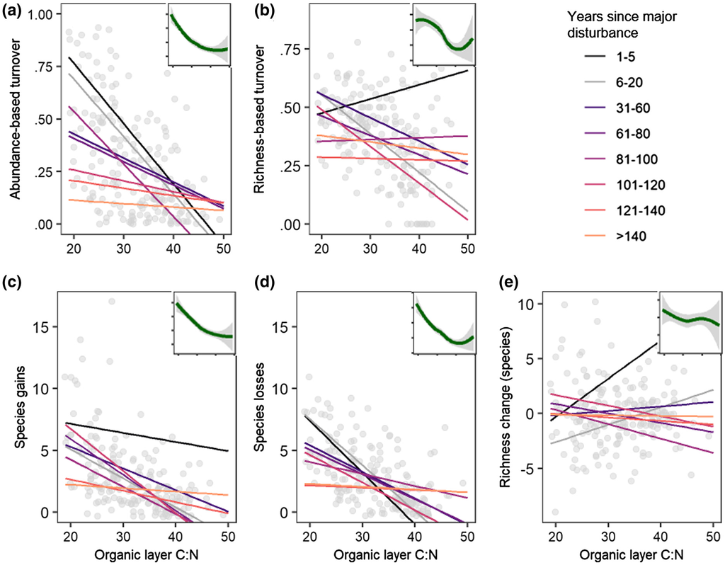

**FIGURE 2**

Temporal community change during a decade in boreal forest understorey in relation to soil fertility in different time‐since‐major‐disturbance categories. Low carbon to nitrogen (C : N) ratio in the soil organic layer indicates fertile soils. Community change during a decade measured with five metrics: (a) relative‐abundance based turnover, (b) richness‐based turnover (the sum of proportions of gained and lost species), (c) species gains, (d) species losses, and (e) change in species richness. Grey dots represent the data from each site (*n* = 169) and coloured lines the linear regression in relation to time since disturbance. Small inserts show smoothed average response of variable in question to organic layer C : N ratio ignoring the disturbance history

TABLE 1. The effects of soil organic layer C : N ratio and time since the latest major disturbance and their interaction on the five measured community change indices. Summary of five generalized linear mixed effect models with each index in turn as a response variable, organic layer C : N ratio, time since disturbance and their interaction as fixed variables and site nested within bioclimatic subzone as a random variable.

|  | Dependent variable Abundance‐based turnover | Dependent variable Richness‐based turnover | Dependent variable Gains | Dependent variable Losses | Dependent variable Richness change |
| --- | --- | --- | --- | --- | --- |
| Constant | 0.15 (0.34) | 0.43 (0.27) | 2.78 (4.16) | 2.74 (3.41) | −0.01 (5.04) |
| Time_since_dist1−5 | 1.20 (0.42)*** | −0.08 (0.34) | 5.83 (5.26) | 13.00 (4.31)*** | −7.25 (6.34) |
| Time_since_dist 6–20 | 1.09 (0.41)*** | 0.45 (0.33) | 6.97 (5.14) | 12.19 (4.21)*** | −5.77 (6.14) |
| Time_since_dist 31–60 | 0.51 (0.39) | 0.32 (0.31) | 5.99 (4.84) | 6.96 (3.96) | −0.94 (5.84) |
| Time_since_dist 61–80 | 0.48 (0.38) | 0.20 (0.30) | 8.91 (4.67) | 6.33 (3.82) | 2.60 (5.65) |
| Time_since_dist 81–100 | 0.89 (0.39)*** | −0.09 (0.31) | 5.84 (4.77) | 3.27 (3.90) | 2.98 (5.77) |
| Time_since_dist 101–120 | 0.22 (0.40) | 0.37 (0.32) | 10.75 (4.94)*** | 6.36 (4.04) | 3.62 (5.91) |
| Time_since_dist 121–140 | 0.13 (0.43) | −0.14 (0.33) | 1.69 (4.98) | −0.21 (4.04) | 0.60 (6.56) |
| CN | −0.002 (0.01) | −0.003 (0.01) | −0.03 (0.11) | −0.02 (0.09) | −0.01 (0.13) |
| Time_since_dist 1–5:CN | −0.03 (0.01)*** | 0.01 (0.01) | −0.05 (0.16) | −0.40 (0.13)*** | 0.35 (0.20) |
| Time_since_dist 6–20:CN | −0.03 (0.01)*** | −0.01 (0.01) | −0.21 (0.14) | −0.35 (0.12)*** | 0.16 (0.17) |
| Time_since_dist 31–60:CN | −0.01 (0.01) | −0.01 (0.01) | −0.15 (0.13) | −0.19 (0.11) | 0.05 (0.16) |
| Time_since_dist 61–80:CN | −0.01 (0.01) | −0.01 (0.01) | −0.26 (0.13) | −0.18 (0.10) | −0.08 (0.15) |
| Time_since_dist 81–100:CN | −0.02 (0.01)*** | 0.003 (0.01) | −0.19 (0.13) | −0.07 (0.11) | −0.13 (0.16) |
| Time_since_dist 101–120:CN | −0.004 (0.01) | −0.01 (0.01) | −0.31 (0.14)*** | −0.20 (0.11) | −0.09 (0.17) |
| Time_since_dist 121–140:CN | −0.002 (0.01) | 0.002 (0.01) | −0.06 (0.13) | 0.004 (0.11) | −0.03 (0.17) |

### Note

- ‘Constant’ refers to the forest stands older than 140 years used as a reference class in the modelling. *n* = 169 for each model. Each column reports the model estimates, followed by its standard error in parentheses. These predictions are illustrated in Figure 2. ANOVA‐table of these model results can be found in Supporting Information Table S3.
- *** *p* < .05.

### 3.2 Importance of species identity shifts for long‐term dynamics of temporal turnover

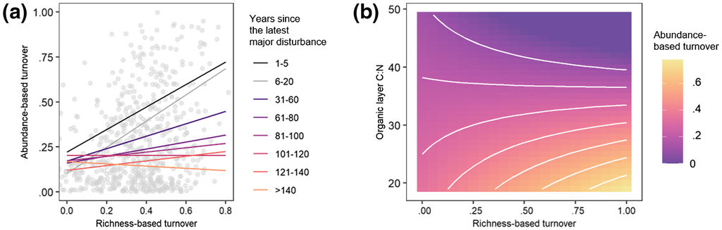

**FIGURE 3**

Relationship between dominance structure change and species identity changes during a decade in relation to time since major disturbance and soil fertility. In (a) the coloured lines represent linear regression model predictions of relative abundance‐based turnover in relation to richness‐based turnover in different time‐since‐disturbance categories (*n* = 533), and (b) predicted abundance‐based turnover (in colour) in relation to richness‐based turnover and soil fertility (*n* = 169). Low organic layer C : N indicates high soil fertility

TABLE 2. The effects of richness‐based turnover (richness‐based species exchange ratio, SERr), time since a major disturbance and their interaction on relative abundance based turnover. Estimates of generalized linear mixed effect model with site nested within cluster and bioclimatic subzone as a random variable.

|  | Abundance‐based turnover |
| --- | --- |
| Constant | 0.17 (0.05)*** |
| Time_since_disturbance1−5 | 0.05 (0.11) |
| Time_since_disturbance 6–20 | −0.07 (0.09) |
| Time_since_disturbance 31–60 | 0.004 (0.07) |
| Time_since_disturbance 61–80 | −0.01 (0.07) |
| Time_since_disturbance 81–100 | 0.004 (0.07) |
| Time_since_disturbance 101–120 | 0.03 (0.08) |
| Time_since_disturbance 121–140 | −0.05 (0.08) |
| Richness‐based turnover (SERr) | −0.06 (0.13) |
| Time_since_disturbance 1–5:SERr | 0.69 (0.24)*** |
| Time_since_disturbance 6–20:SERr | 0.79 (0.23)*** |
| Time_since_disturbance 31–60:SERr | 0.41 (0.18)*** |
| Time_since_disturbance 61–80:SERr | 0.26 (0.18) |
| Time_since_disturbance 81–100:SERr | 0.18 (0.19) |
| Time_since_disturbance 101–120:SERr | 0.07 (0.20) |
| Time_since_disturbance 121–140:SERr | 0.19 (0.23) |

### Note

- ‘Constant’ refers to the forest stands older than 140 years used as a reference class in the modelling. Standard errors of model estimates are in parentheses. *n* = 533.
- *** *p* < .05.

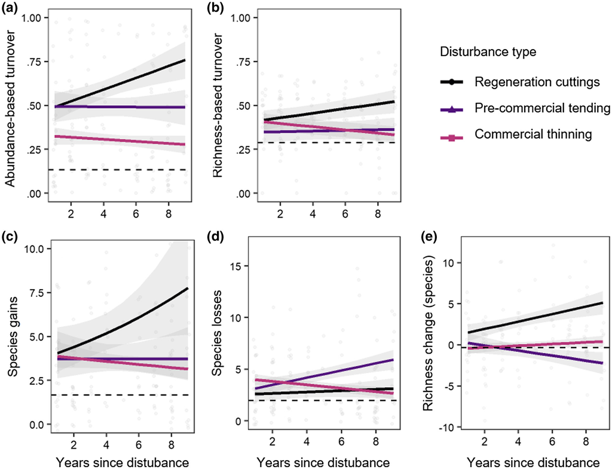

**FIGURE 4**

First decade’s temporal community change in boreal forest understorey in response to time since disturbance under different disturbance types. Community change from pre‐ to post‐disturbance community measured by five metrics: (a) abundance‐based turnover, (b) richness‐based turnover, (c) species gains, (d) species losses, and (e) change in species richness. Grey dots describe the original data from each site (*n* = 142), coloured lines show the generalized linear models ± *SE* for different disturbance types. For comparison, the dashed line indicates average community change during a decade without disturbance in forests older than 140 years. Soil C : N ratio was held constant at its mean for these predictions

### 3.3 Short‐term effects of disturbance on temporal turnover depend on disturbance intensity

All disturbances, regardless of their intensity, taking place between the sampling events (i.e., between 1985 and 1995) triggered a greater compositional turnover in forest understorey than observed in the oldest forest stands without disturbance between the sampling events (Figure 4, dashed line for the oldest forests). Relative abundance‐based turnover tended to increase during the first decade after a regeneration cutting (marginally significant effect of time, Table 3, *p* = .081), while commercial thinning slightly decreased both abundance‐ and richness‐based turnover during the first decade (Figure 4a,b, Table 3). Regeneration cuttings increased species gains on average from four species during the first year to eight species nine years after the disturbance, while after thinning the number of species gains diminished from on average four to three species during the first decade (Figure 4c, Table 3). Number of lost species was not influenced by disturbance type and remained stable (on average four species lost) during the first decade (Figure 4d, Table 3). Richness change was positive and tended to increase from the first to ninth year after regeneration cutting, while it was negative and diminished from the third to ninth year after pre‐commercial tending. Soil fertility increased all turnover metrics except richness change during the first decade after the disturbance regardless of disturbance type (Supporting Information Figure S5, Table 3).

TABLE 3. Effects of disturbance type, time since disturbance and soil fertility on temporal community change 1–9 years after disturbance. Results of generalized mixed effect analysis modelling each of the community change metrics as a response of two 2‐way interactions: disturbance type × time since disturbance; and disturbance type × soil fertility.

|  | Dependent variable: Abundance‐based turnover | Dependent variable: Richness‐based turnover | Dependent variable: log(Gains + 1) | Dependent variable: Losses | Dependent variable: Richness change |
| --- | --- | --- | --- | --- | --- |
| Constant | 0.99 (0.25)*** | 0.73 (0.14)*** | 3.72 (0.50)*** | 11.70 (2.34)*** | 5.28 (3.30) |
| Tending | −0.02 (0.36) | −0.07 (0.18) | −0.41 (0.71) | −1.63 (3.24) | −4.88 (4.72) |
| Thinning | −0.26 (0.28) | −0.05 (0.14) | −0.63 (0.57) | −0.23 (2.58) | −6.22 (3.77) |
| years_since | 0.03 (0.02)* | 0.01 (0.01) | 0.08 (0.04)** | 0.06 (0.17) | 0.46 (0.25)+ |
| soil_CN | −0.02 (0.01)** | −0.01 (0.004)*** | −0.08 (0.02)*** | −0.32 (0.08)*** | −0.15 (0.11) |
| Tending:years_since | −0.03 (0.03) | −0.01 (0.01) | −0.08 (0.06) | 0.28 (0.25) | −0.76 (0.37)* |
| Thinning:years_since | −0.04 (0.02)* | −0.02 (0.01)** | −0.11 (0.04)** | −0.23 (0.20) | −0.35 (0.29) |
| Tending: soil_CN | 0.002 (0.01) | 0.001 (0.01) | 0.01 (0.02) | 0.07 (0.10) | 0.15 (0.15) |
| Thinning: soil_CN | 0.005 (0.01) | 0.002 (0.005) | 0.02 (0.02) | 0.06 (0.08) | 0.16 (0.12) |

### Note

- ‘Constant’ refers to regeneration cuttings, which were set as a reference category for disturbance type when modelling. Each column reports the model estimates, followed by standard error in parentheses. *n* = 142 in each model.
- * *p* < .1;
- ** *p* < .05;
- *** *p* < .01.

## 4 DISCUSSION

We found that the long‐term dynamics of temporal turnover in vascular plant communities in boreal forest is driven jointly by time since disturbance and fertility. The greatest turnover occurred in the most fertile forest stands during the first decade after a major disturbance, such as clear‐cutting, but fertility was not a driver of community change in the oldest forests. These findings provide two novel aspects on the emerging view that spatial heterogeneity [also enabling a larger regional species pool via spatial storage effect (Chesson, 2000)] may result in higher temporal turnover (Hodapp et al., 2018). First, our findings reveal that disturbance history, which in forest systems is mirrored by successional stage, is strongly controlling temporal turnover. Disturbances may thus increase temporal turnover by directly altering species composition or by increasing spatial heterogeneity in the landscape. Second, we observe the greatest turnover in recently disturbed forest stands. These young stands are typically characterized by rapidly changing light and microclimatic conditions as a consequence of fast canopy development (Brown & Parker, 1994; Hart & Chen, 2006; Kuuluvainen et al., 1993). This suggests that also temporal heterogeneity in the environment (i.e., temporal storage effect) may increase community turnover.

Our results demonstrate that high turnover in fertile habitats immediately after disturbance was driven by high numbers of species gains and losses leading to changes in the community dominance structure. There are at least two possible and mutually non‐exclusive explanations for this pattern. First, the species colonizing the forest stand immediately after a major disturbance are typically ruderals [as described by Grime’s plant strategy framework (1974)], usually characterized by fast growth, short life cycles, high seed production and poor shade‐tolerance (Tonteri et al., 2016; Vanha‐Majamaa et al., 2017; Zobel, 1989). Their existence is by definition short, thus swiftly giving space for new colonizers and thereby potentially contributing to the rapid temporal turnover observed in this study. This inference is supported by several studies summarized by Collins et al. (2018), who found higher temporal turnover in communities dominated by organisms with short life spans. Since fertile habitats should generally support plants with fast nutrient acquisition and resource use strategies (Chapin et al., 1993; Jager et al., 2015; Lehsten & Kleyer, 2007; Wright et al., 2001), these fast‐growing species are likely to make up a greater proportion of the regional species pool in fertile than in nutrient‐poor sites and thereby contribute to the observed higher turnover in fertile habitats.

Second, faster turnover in young fertile forest stands can also be driven by larger local species pools in fertile sites, supplying a diverse array of candidate colonizers with varying environmental preferences. In our dataset, soil fertility correlates with local species richness, but soil fertility explained a greater proportion of variation in temporal turnover than richness did (see Materials and methods). Supporting both of these explanations, Heikkinen and Mäkipää (2010) show that forest plants occupying the nutrient‐rich end of the soil C : N gradient have narrower niches, and thus more specialized nutrient requirements than species preferring more nutrient‐poor sites. On the scale of the whole of Finland, the regional pool thus has more candidate colonizers to offer for fertile sites than for nutrient‐poor sites. Moreover, a large species pool is likely to include species that are sufficiently different from the resident species to enable coexistence (Chesson, 2000; Chesson & Huntly, 1997). High temporal heterogeneity in the environmental conditions during the first decades after the forest establishment (especially light, as canopy develops) may lead to shorter coexistence times and higher turnover, as predicted by models by Adler and Drake (2008), if the first colonizing species have narrow niches and hence do not tolerate changing environmental conditions, as the forest canopy develops.

We note that the ultimate drivers of temporal turnover may differ in time. Time since disturbance serves here as a proxy for a suite of variables that change with time after a disturbance. During the first decades of stand development, light, microclimatic conditions and soil moisture experienced by the understorey plants change drastically as the tree canopy develops from open to fully closed (Brown & Parker, 1994; Hart & Chen, 2006; Kuuluvainen et al., 1993). These environmental changes are here modelled under the umbrella of ‘time since disturbance’ covering potentially several covarying abiotic and biotic factors. Future experimental studies are necessary to disentangle the relative contributions of these covarying factors on community composition.

Many of the colonizers throughout the succession are so‐called transient species, which may be poorly adapted to the biotic and abiotic environment and therefore not able to sustain permanent populations (Taylor et al., 2018). Forest is an especially challenging environment for a plant species to thrive due to its continuously changing micro‐environmental conditions below developing tree canopies (Hart & Chen, 2006). The stabilization of the dominance structure is a continuous phenomenon during natural forest succession, as canopy closure increases (Angelstam & Kuuluvainen, 2004; Bergeron & Dubue, 1988; Hedwall et al., 2019; Rees & Juday, 2002), but our results suggest that in boreal forests the age of *c*. 60–80 years may be a milestone, after which dominance structure of understorey communities becomes more stable and is not influenced by transient species losses or gains.

Our findings highlight the importance of species gains for turnover during the first two decades after a disturbance, when the sites gained species with time following a regeneration cutting (Figure 4c,e, Supporting Information Figure S2b.c, Table 3) and more so on fertile than infertile soils (Supporting Information Figure S5c,e, Table 3). It is not surprising that species gains are important, as most of the vegetation is typically destroyed because of silvicultural regeneration practices, and bare soil openings enhance establishment of arriving species. This is broadly in line with results from a Canadian tree community study, which found that major disturbances increase both species gains and losses of tree species compared to moderate and minor disturbances, while minor disturbances trigger more gains than losses (Brice et al., 2019). Many gained species belong to the local species pool and re‐establish in the sites from the seedbank, rhizomes or roots. These are so‐called core species (sensu Magurran & Henderson, 2003), occurring throughout virtually all successional stages (Nieppola, 1992; Tonteri, 1994; Zobel, 1989). However, by comparing communities before and after a disturbance, we found that the number of gained species (which were absent from the above‐ground communities in a site before the disturbance) increased during the first two decades. This increasing trend suggests that gained species may include also colonizers from outside of the site. Species losses also contributed to turnover especially in recently disturbed sites on fertile soils. We did not find a temporal trend in species losses nor differences in number of lost species between different disturbance types. In this dataset, on average four species were lost from a site during the first two decades and those species did not re‐colonize the sites during the first two decades. The species that disappeared were likely to be transient species, perhaps with narrow niches reducing their probability of re‐establishing at the site after a management action and following changes in environmental conditions. Our results highlight the importance of disturbance both for the long‐ and short‐term dynamics of temporal turnover, supporting Brice et al., (2019), who found that disturbance is a stronger driver of Canadian tree communities than climate change.

Our findings based on a unique long‐term observational dataset on vascular plant communities in the understorey illustrate the prominent role of the large‐scale soil fertility gradient in controlling temporal turnover in combination with disturbance history. They suggest that a simple measure of soil fertility may serve as a good predictor for temporal turnover in response to disturbance at least in boreal forests. Moreover, our results reveal that species gains and losses alter the dominance structure of the communities in fertile habitats and following disturbance, potentially leading to changes in ecosystem functioning. While some identity shifts take place also in the oldest forests, there they do not translate to changes in dominance structure. For a more comprehensive understanding of biodiversity changes in boreal forests, future studies should consider also bryophytes and lichens, which increase relative to vascular plants when forests become older. However, our results on vascular plants suggest, that if clear‐cuttings become more frequent in space, as observed in Finland during recent years (Peltola et al., 2019), a larger proportion of forest area will belong to the recently disturbed category and can be colonized by new species. This calls attention to functional characteristics of colonizers: if they include generalists with good competitive abilities, in the long term the high colonization rates may lead to homogenization of forest plant communities, as observed in Denmark over the past 140 years (Finderup Nielsen et al., 2019). Moreover, it is important to understand how different functional groups are changing in response to disturbance given that functional community composition is strongly linked with ecosystem functioning (Allan et al., 2011). Adaptability of ecosystems to future changes is dependent on their biodiversity (Eriksson & Hillebrand, 2019). Consequently, biotic homogenization may lead to a lower adaptive capacity and a decrease in ecosystem resilience.

## ACKNOWLEDGMENTS

We thank all field workers, laboratory and data management staff at Luke for their valuable work. We thank Laura Antão for her helpful comments on the previous version and Tanja Lindholm, Bess Hardwick and Manuel Frias for their assistance with data management and maps. The study was supported by funding from the Jane and Aatos Erkko Foundation to the Research Centre for Ecological Change. The sampling in 2006 was co‐funded by the BioSoil project carried out under the Forest Focus scheme [European Commission Regulation Nr. 2152/2003].

## AUTHOR CONTRIBUTIONS

The field study was designed and carried out by The Natural Resources Institute Finland. TT and MS participated in organizing the data collection and preparing data for statistical analysis. EK defined the study questions, performed the analysis and wrote the first draft of the manuscript, and all authors contributed to writing.

## Open Research

## Supporting Information

## REFERENCES

## BIOSKETCH

The author team consists of plant and forest ecosystem ecologists with diverse backgrounds including forest inventories, community and spatial ecology. This work is a collaborative effort to enhance our understanding of the ecological drivers of biodiversity changes using long‐term data collected in Finland during past decades.

[figure not shown]

[Volume30, Issue2](https://onlinelibrary.wiley.com/toc/14668238/2021/30/2)

February 2021

Pages 476-489

### Metrics

### Details

- © 2020 The Authors. *Global Ecology and Biogeography* published by John Wiley & Sons Ltd

  This is an open access article under the terms of the [Creative Commons Attribution‐NonCommercial](http://creativecommons.org/licenses/by-nc/4.0/) License, which permits use, distribution and reproduction in any medium, provided the original work is properly cited and is not used for commercial purposes.

[figure not shown]

### Keywords

  - [beta diversity](https://onlinelibrary.wiley.com/action/doSearch?field1=Keyword&text1=beta%20diversity)
  - [clear‐cut](https://onlinelibrary.wiley.com/action/doSearch?field1=Keyword&text1=clear%E2%80%90cut)
  - forestry
  - gains
  - losses
  - nitrogen
  - nutrient
  - richness
  - succession
  - [temporal turnover](https://onlinelibrary.wiley.com/action/doSearch?field1=Keyword&text1=temporal%20turnover)

### Funding Information

  - Jane ja Aatos Erkon Säätiö

### Publication History

  - Issue Online: 20 January 2021
  - Version of Record online: 08 December 2020
  - Manuscript accepted: 30 October 2020
  - Manuscript revised: 26 October 2020
  - Manuscript received: 25 May 2020